# COVID-19 Forest Plots

Jaqueline Passos, Izonete Cristina Guiloski e [Henrique Laureano](https://henriquelaureano.github.io/)

Last modification on* 2022-07-03 11:32:09

> Número de participantes com COVID-19 e o sintoma de perda de olfato

> Forest plot meta-analysis of the prevalence of olfactory dysfunctions in COVID-19 patients across studies. Random-effects models are presented. Individual study estimates are represented as black boxes on the continuous horizontal line, which represents the 95% CI.

> *Reference*: Viechtbauer, W. (2010). Conducting meta-analyses in R with the metafor package. Journal of Statistical Software, 36(3), 1-48. https://doi.org/10.18637/jss.v036.i03

> **Anosmia**: Cochran’s Q (Q=193.71, df=13, p<0.001), approximated from the chi-square distribution, is significant, and the $I^{2}$ value of 90.8%, confirming the heterogeneity of the meta-analysis across the subjective studies. The pooled estimate for the prevalence for the overall cohort was 61% with a 95% CI of 49-72%.

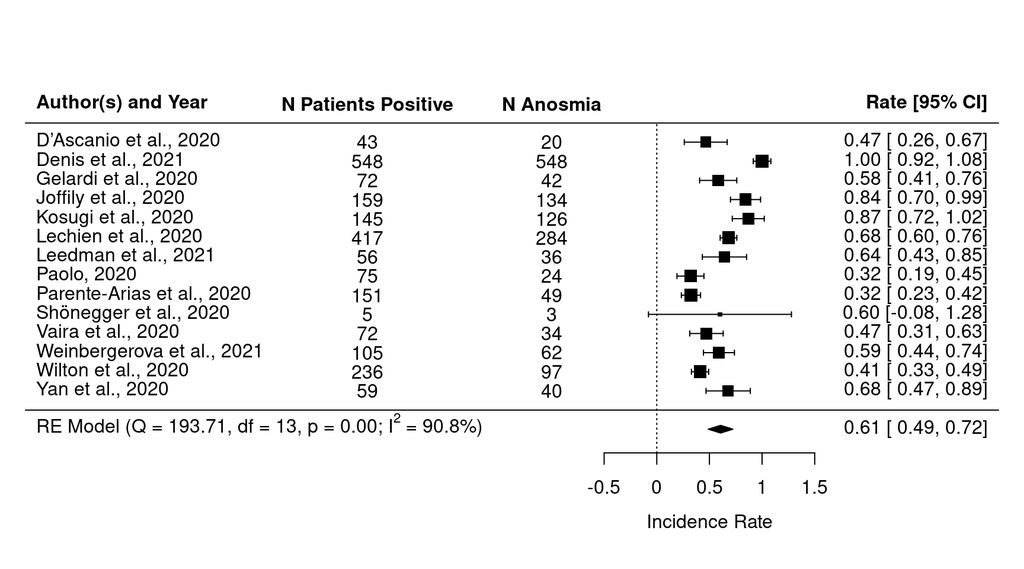

> **Hyposmia**: Cochran’s Q (Q=32.99, df=7, p<0.001), approximated from the chi-square distribution, is significant, and the $I^{2}$ value of 94.4%, confirming the heterogeneity of the meta-analysis across the subjective studies. The pooled estimate for the prevalence for the overall cohort was 21% with a 95% CI of 9-32%.

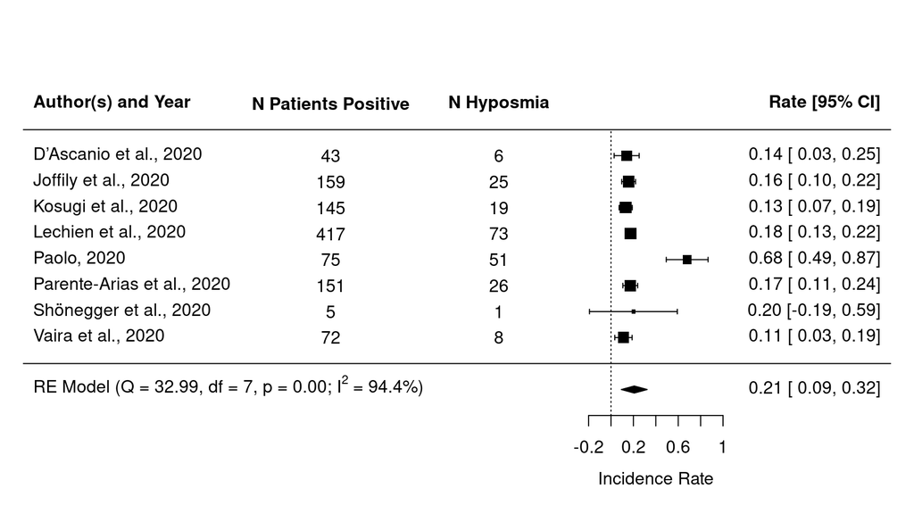

> **Ageusia**: Cochran’s Q (Q=328.23, df=7, p<0.001), approximated from the chi-square distribution, is significant, and the $I^{2}$ value of 97.2%, confirming the heterogeneity of the meta-analysis across the subjective studies. The pooled estimate for the prevalence for the overall cohort was 46% with a 95% CI of 26-66%.

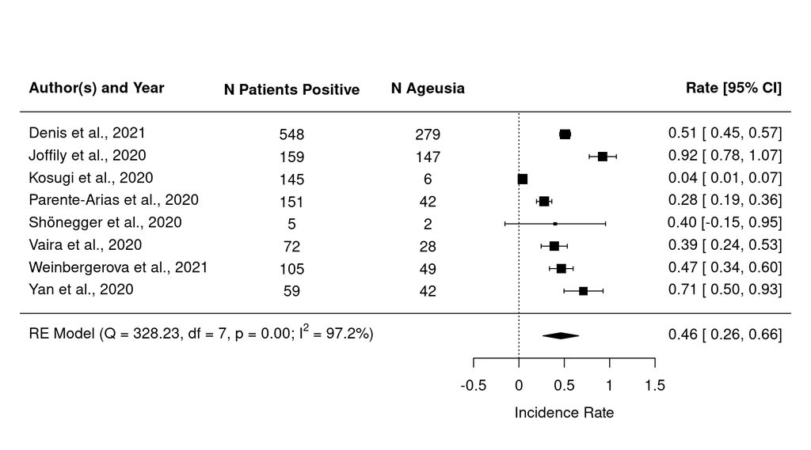

> **Dysgeusia**: Cochran’s Q (Q=179.12, df=5, p<0.001), approximated from the chi-square distribution, is significant, and the $I^{2}$ value of 96.8%, confirming the heterogeneity of the meta-analysis across the subjective studies. The pooled estimate for the prevalence for the overall cohort was 53% with a 95% CI of 24-82%.

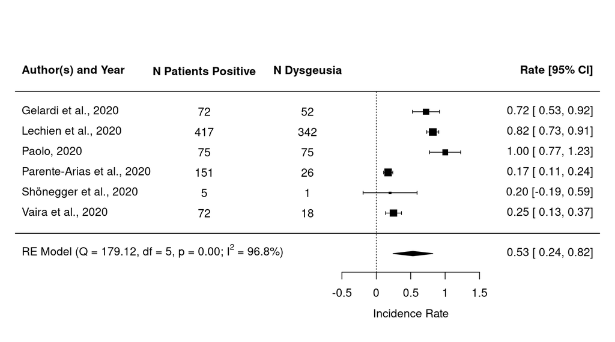

> **Until 15 days**: Cochran’s Q (Q=162.5, df=8, p<0.001), approximated from the chi-square distribution, is significant, and the $I^{2}$ value of 93.4%, confirming the heterogeneity of the meta-analysis across the subjective studies. The pooled estimate for the prevalence for the overall cohort was 46% with a 95% CI of 30-61%.

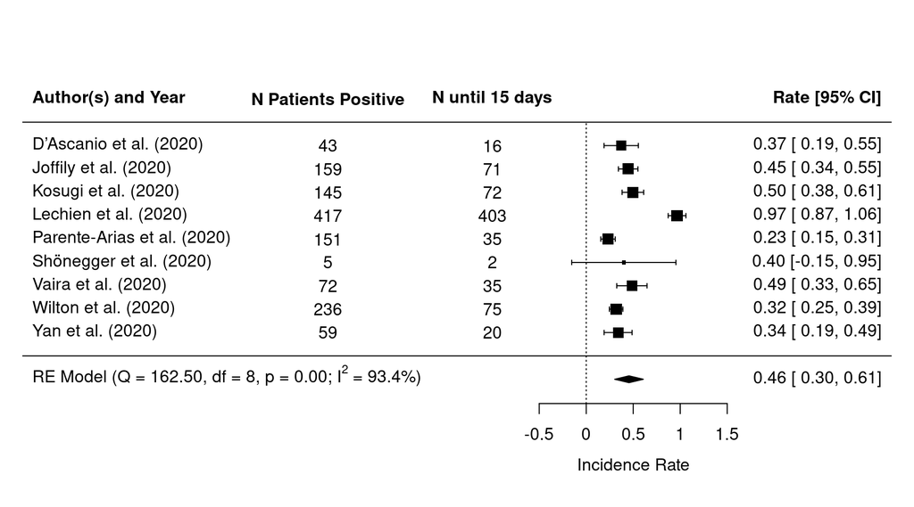

> **After 15 days**: Cochran’s Q (Q=763.63, df=13, p<0.001), approximated from the chi-square distribution, is significant, and the $I^{2}$ value of 98.3%, confirming the heterogeneity of the meta-analysis across the subjective studies. The pooled estimate for the prevalence for the overall cohort was 44% with a 95% CI of 28-60%.

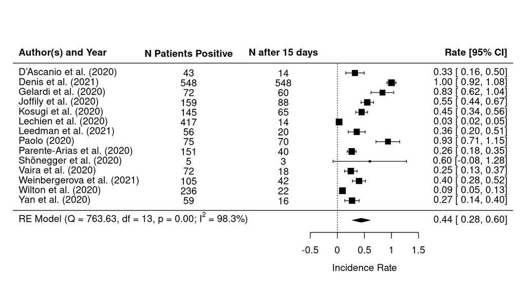

> **Publication bias under the funnel plot**. The desired behavior is all points symmetrically dispersed around zero, and all (ideally) in the white background region.

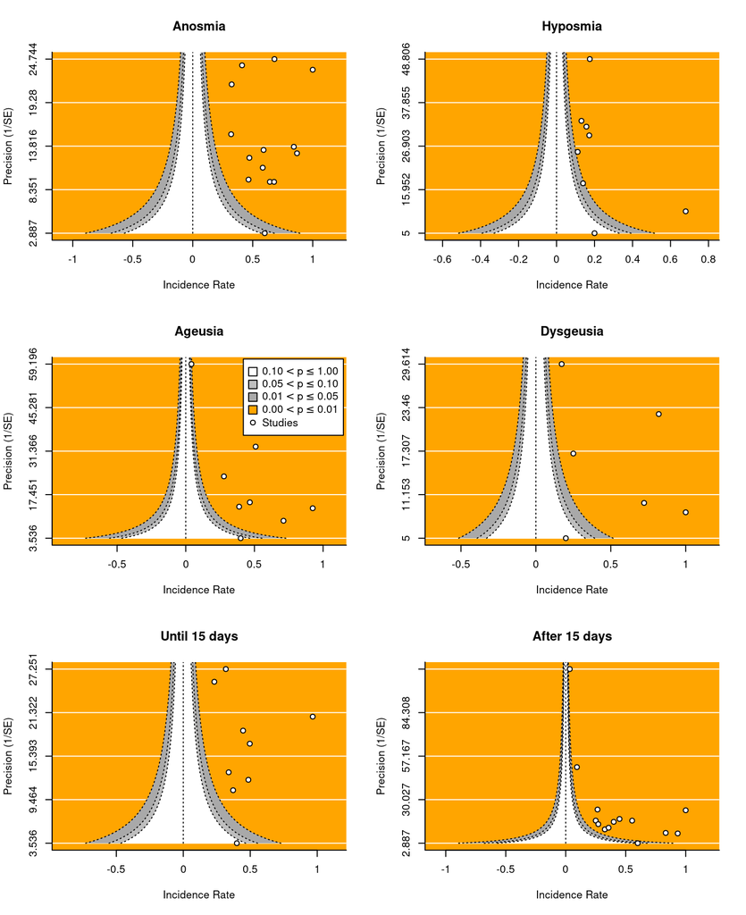